# LAB10_Apredizaje No Supervisado

We

2 de marzo de 2020

### (Tomado de Introduction to Statistical Learning with Applications in R, by G. James,D. Witten, T.Hastie, R. Tibshirani)

[figure not shown]

```r
#install.packages("ISLR")
library(ISLR)
data("USArrests")
states =row.names(USArrests )
head(USArrests)
```

```
##            Murder Assault UrbanPop Rape
## Alabama      13.2     236       58 21.2
## Alaska       10.0     263       48 44.5
## Arizona       8.1     294       80 31.0
## Arkansas      8.8     190       50 19.5
## California    9.0     276       91 40.6
## Colorado      7.9     204       78 38.7
```

# Análisis de componentes principales (PCA)

Primero examinamos brevemente los datos. Notamos que las variables poseen medias muy diferentes

```r
apply(USArrests , 2, mean)
```

```
##   Murder  Assault UrbanPop     Rape
##    7.788  170.760   65.540   21.232
```

Vemos que hay en promedio tres veces más violaciones que asesinatos, y más de ocho veces más asaltos que violaciones. También podemos examinar las varianzas de las cuatro variables usando la función $\texttt{apply()}$.

```r
apply(USArrests , 2, var)
```

```
##     Murder    Assault   UrbanPop       Rape
##   18.97047 6945.16571  209.51878   87.72916
```

No es sorprendente que las variables también tengan varianzas muy diferentes: La variable $\texttt{UrbanPop}$ mide el porcentaje de la población en cada estado que vive en el área urbana, dicho número no es comparable al número de violaciones en cada estado por cada 100,000 individuos. Si no logramos escalar las variables antes de realizar PCA, entonces la mayoría de las componentes principales que observamos serían impulsadas por la variable **Asalto**, ya que tiene de lejos la mayor media y varianza. Por lo tanto, es importante estandarizar las variables para tener media cero y desviación estándar de uno, antes de realizar PCA.

Ahora realizamos el análisis de componentes principales utilizando la función $\texttt{prcomp()}$, la cual es una de varias funciones en R que realizan PCA.

```r
pr.out =prcomp (USArrests , scale =TRUE)
```

Por defecto, la función $\texttt{prcomp()}$ centra las variables para que tengan una media cero. También al usar la opción $\texttt{scale = TRUE}$, escalamos las variables para tener una desviación estándar de uno. La salida de $\texttt{prcomp()}$ contiene varias cantidades útiles.

```r
names(pr.out )
```

```
## [1] "sdev"     "rotation" "center"   "scale"    "x"
```

Los componentes de $\texttt{centro}$ y $\texttt{escala}$ corresponden a los medias y a la desviación estándar de las variables que fueron escaladas antes de implementar PCA.

```r
pr.out$center
```

```
##   Murder  Assault UrbanPop     Rape
##    7.788  170.760   65.540   21.232
```

```r
pr.out$scale
```

```
##    Murder   Assault  UrbanPop      Rape
##  4.355510 83.337661 14.474763  9.366385
```

La matriz de rotación proporciona los pesos de las componentes principales; cada columna de $\texttt{pr.out\$rotation}$ contiene el vector de pesos de la correspondiente componente principal.

```r
pr.out$rotation
```

```
##                 PC1        PC2        PC3         PC4
## Murder   -0.5358995  0.4181809 -0.3412327  0.64922780
## Assault  -0.5831836  0.1879856 -0.2681484 -0.74340748
## UrbanPop -0.2781909 -0.8728062 -0.3780158  0.13387773
## Rape     -0.5434321 -0.1673186  0.8177779  0.08902432
```

Esta función se denomina matriz de rotación, porque cuando multiplicamos la matriz Matriz $\boldsymbol{X}$ por $\texttt{pr.out\$rotation}$, nos da las coordenadas de los datos originales en el sistema coordinado rotado. Estas coordenadas son los puntajes (scores) de las componentes principales.

Vemos que hay cuatro componentes principales distintos. Esto es esperado porque hay en general $\min(n - 1, p)$ principal informativo componentes en un conjunto de datos con n observaciones y p variables.

Con el uso de la función $\texttt{prcomp()}$, no necesitamos multiplicar explícitamente los datos por los vectores de pesos de las componentes principales para obtener los vectores de scores de componentes principales. Recuerde que
$$\begin{equation}
\boldsymbol{X}\Phi=Z.
\end{equation}$$

Más bien, la matriz $50\times 4$ ($\boldsymbol{Z}$) posee como columnas los vectores de puntuación de las componentes principales. Es decir, la columna $k$ de $\boldsymbol{Z}$ corresponde al $k$-ésimo vector de scores de la componente principal correspondiente.

```r
dim(pr.out$x)
```

```
## [1] 50  4
```

Podemos realizar un plot de los dos primeros componentes principales de la siguiente manera

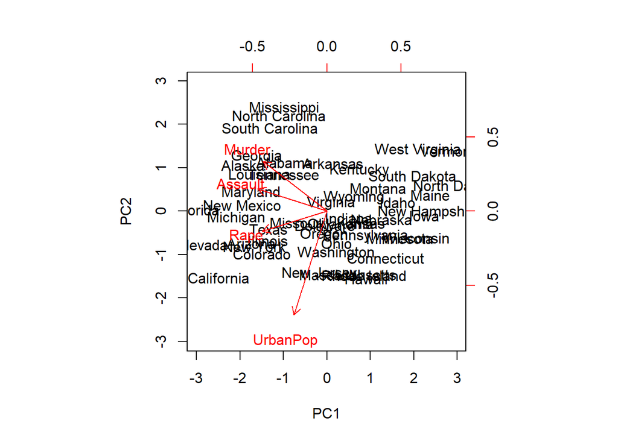

```r
biplot(pr.out,scale =0)
```

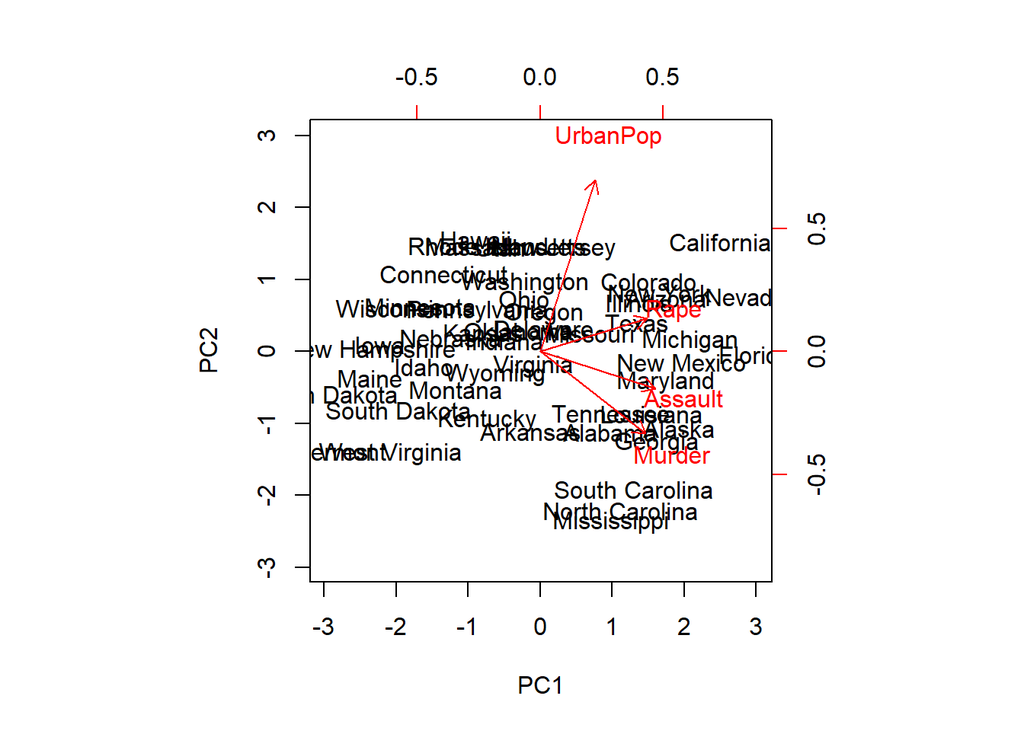

```r
pr.out$rotation=-pr.out$rotation
pr.out$x=-pr.out$x
biplot (pr.out , scale =0)
```

La función $prcomp()$ también proporciona la desviación estándar de cada componente principal. Por ejemplo, en el conjunto de datos de $\texttt{USArrests}$, podemos acceder a estas desviaciones estándar:

```r
pr.out$sdev
```

```
## [1] 1.5748783 0.9948694 0.5971291 0.4164494
```

Elevando estas al cuadrado se consigue la varianza explicada por cada componente

```r
pr.var =pr.out$sdev ^2
pr.var
```

```
## [1] 2.4802416 0.9897652 0.3565632 0.1734301
```

Para calcular la proporción de varianza explicada por cada componente principal, simplemente dividimos la varianza explicada por cada componente principal por la varianza total explicada por los cuatro componentes principales:

```r
pve=pr.var/sum(pr.var )
pve
```

```
## [1] 0.62006039 0.24744129 0.08914080 0.04335752
```

se puede ver que el primer componente principal explica el 62.0% de la varianza en los datos, el siguiente componente principal explica el 24.7% de la varianza, Etcétera. También se puede realizar un plot de la PVE explicada por cada componente como la PVE acumulada, como sigue

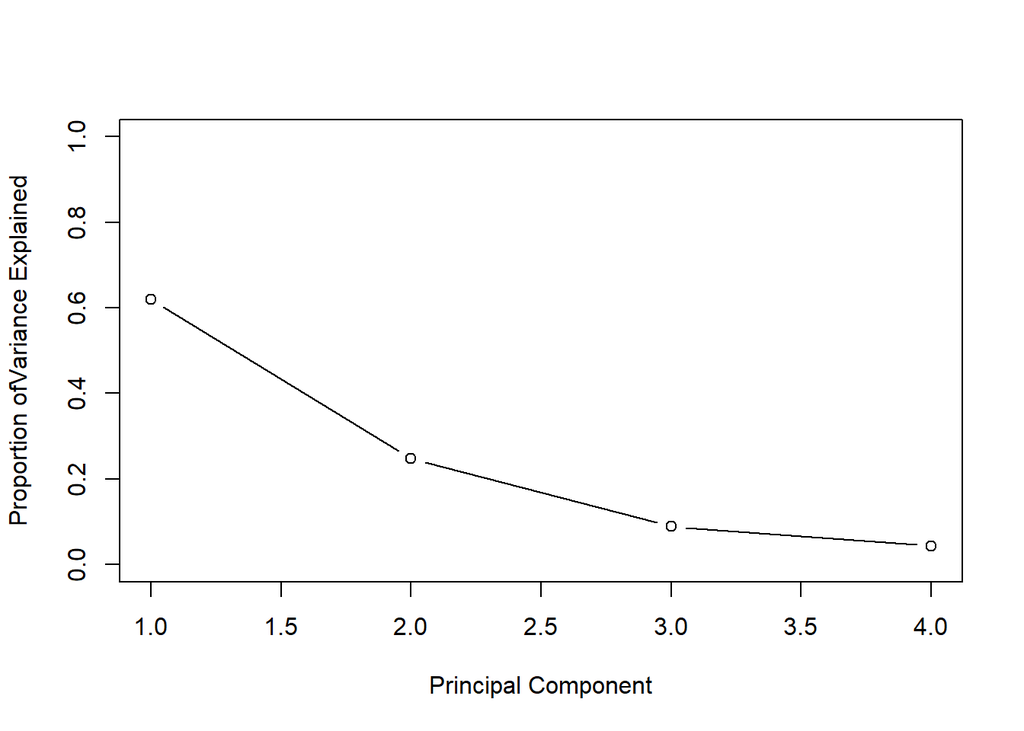

```r
plot(pve, xlab="Principal Component", ylab="Proportion ofVariance Explained",ylim=c(0,1) ,type='b')
```